# Insurance Premium Default Propensity Prediction

Rajeev Nitnawre

25/11/2021

# **Project 3 - Insurance Premium Default Propensity Prediction**

Taking the project ahead after submission of Project Notes 1 & Project Notes 2 where we did the following:

1. Introduction: Define the problem statement, need of the present study and business/social opportunity
2. Data Report
3. Initial Exploratory Data Analysis
4. Data pre-processing
5. Exploratory Data Analysis
6. Alternative analytical approaches

## Project Objective for Project Notes 3:

Premium paid by the customer is the major revenue source for insurance companies. Default in premium payments results in significant revenue losses and hence insurance companies would like to know upfront which type of customers would default premium payments.

**The objective of this project** * Thorough report on the modeling process and how to built on the initial analysis to increase the accuracy of the model. * The insights, conclusion and business interpretation.

## Project Notes 3:

This Project Notes 3 submission will be about:

1. **Modeling Process (validation & interpretation)**
2. **Model comparisons (confusion matrix, ROC, AUC, SSE whichever is applicable)**
3. **Ensemble modeling, wherever applicable**
4. **Interpretation from the best model**
5. **Business insights**

#### 1. Data pre-processing

```r
knitr::opts_chunk$set(error = FALSE,     # suppress errors
                      message = FALSE,   # suppress messages
                      warning = FALSE,   # suppress warnings
                      echo = FALSE,      # suppress code
                      cache = TRUE)      # enable caching
```

#### 1.1 Environment Set up and Data Import

#### 1.1.1 Install necessary Packages and Invoke Libraries

# 1.2 Import and Read the Dataset

#### 1.3.a Variable Transformation- Convert “Age in Days” variable to “Age” - in years

**VARIABLE TRANSFORMATION:** The “Age in Days” column is used to create a new variable column of ’Age" which is represented in years.

#### 1.3.b Variable Transformation- dividing “Income” by 1000

#### 1.4 Addition of New variables - Adding a new variable ’agegroup" to bucket the age in groups

**ADDING A NEW VARIABLE - “agegroup”:** The “age” - in years is used to create a new feature variable i.e. Age Group. The age component is slotted into eight buckets from lowest to highest in ascending order. The eight age groups are as follows

- 1 = Ages between 12 & 29
- 2 = Ages between 30 & 39
- 3 = Ages between 40 & 49
- 4 = Ages between 50 & 59
- 5 = Ages between 60 & 69
- 6 = Ages between 70 & 79
- 7 = Ages between 80 & 89
- 8 = Ages between 90 & 103

#### 1.5 Removal of unwanted variables

```
## [1] 79853    17
```

**DROPPING THE UNWANTED VARIABLES FROM THE DATA SET:**

###Change name of variables

*Changing names of the variable with space or ‘-’ to avoid errors while building models.

#### 1.6 Outlier treatment

#### 1.6.a.. Age

#### 1.6.b. Income

#### 1.6.c.Premium

#### 1.6.d. no_of_premiums_paid

####1.6.e. Premium paid in Cash

####1.6.f. ‘Count_3-6_months_late’

####1.6.g. Count_6-12_months_late

####1.6.h. Count_more_than_12_months_late

#### 1.7 Create a subset of the numerical variables

**No high correlation** observed between any numerical variables.

#### 1.8 Ensure that the target variable is a factor & Rename the levels & Relevel

```
## [1] "Defaulters"     "Non_Defaulters"
```

#### 1.9 Retain “age” and remove the variable “Age Group” after EDA

#### 1.10 Correlation plot between numerical variavles

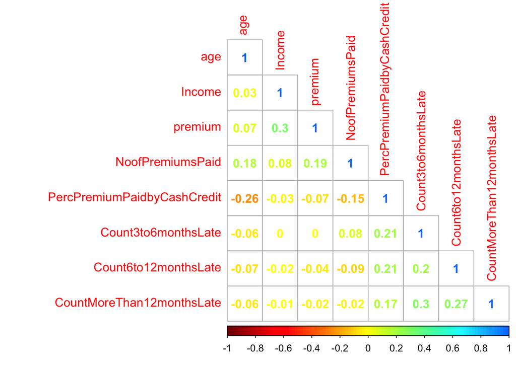

As observed **No high correlation** observed between any numerical variables.

## 2. Modelling: Create Multiple Models

#### 2.1 Split the Data into Train & Test (80-20 split)

```
##
##     Defaulters Non_Defaulters
##       6.259881      93.740119
```

```
##
##     Defaulters Non_Defaulters
##       6.255479      93.744521
```

```
##
##     Defaulters Non_Defaulters
##       6.259001      93.740999
```

- The newly form Train & Test data have similar distribution of the dependent variable.

## 3. Model Processing

```
##
##     Defaulters Non_Defaulters
##           3999          59884
```

```
##
##     Defaulters Non_Defaulters
##     0.06259881     0.93740119
```

```
##
##     Defaulters Non_Defaulters
##       25.50336       74.49664
```

```
##
##     Defaulters Non_Defaulters
##         151962         443889
```

#### Define the training control

### 3.2 Model 1 - CART Model

#### 3.2.a. Cart Model 1

#### Built Cart Model on train data set,use the “rpart” and the “rattle” libraries to build decision trees.

- We will need to prune this decision tree

#### Model Tuning

The cost complexity table can be obtained using the printcp or plotcp functions

```
##
## Classification tree:
## rpart(formula = default ~ ., data = PremiumData_Train, method = "class",
##     control = r.ctrl)
##
## Variables actually used in tree construction:
##  [1] age                         Count3to6monthsLate
##  [3] Count6to12monthsLate        CountMoreThan12monthsLate
##  [5] Income                      MaritalStatus
##  [7] NoofDep                     NoofPremiumsPaid
##  [9] PercPremiumPaidbyCashCredit premium
## [11] ResidenceAreaType           riskScore
## [13] SourcingChannel             VehOwned
##
## Root node error: 3999/63883 = 0.062599
```

[output cut: 29 more lines]

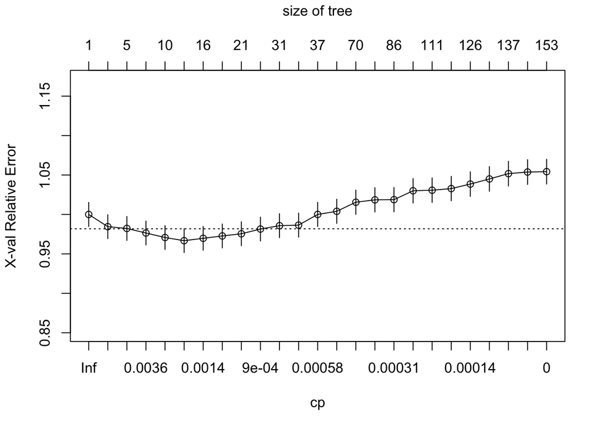

- Age
- Income
- perc_premium_paid_by_cash_credit
- Count_6to12_months_late
- Risk_Score

### Cart Model 2

```
##
## Classification tree:
## rpart(formula = default ~ ., data = PremiumData_Train, method = "class",
##     control = r.ctrl)
##
## Variables actually used in tree construction:
## character(0)
##
## Root node error: 3999/63883 = 0.062599
##
## n= 63883
##
##      CP nsplit rel error xerror    xstd
## 1 0.062      0         1      1 0.01531
```

```
## n= 63883
##
## node), split, n, loss, yval, (yprob)
##       * denotes terminal node
##
## 1) root 63883 3999 Non_Defaulters (0.06259881 0.93740119) *
```

Let us check the variable importance

```
##        Count6to12monthsLate PercPremiumPaidbyCashCredit
##                 737.8686722                 260.7226062
##         Count3to6monthsLate   CountMoreThan12monthsLate
##                 177.9549714                 135.1475952
##                   riskScore                      Income
##                 104.4563936                 103.2502069
##            NoofPremiumsPaid                         age
##                  87.7172972                  61.1264656
##                     premium             SourcingChannel
##                  51.7482048                  21.5210512
##                    VehOwned                     NoofDep
##                   6.5371222                   4.8947900
##               MaritalStatus           ResidenceAreaType
##                   4.8097249                   3.8338214
##                Accomodation
##                   0.2595493
```

- Top Important Variable according to the CART model are:
1. Count 6to 12 months Late
2. Perc Premium Paid by Cash Credit
3. Count 3 to 6 months Late
4. Count More Than 12 months Late
5. risk Score
6. Income

#### Model Validation

```
##                 train_predict.class_CART
##                  Defaulters Non_Defaulters
##   Defaulters              0           3999
##   Non_Defaulters          0          59884
```

```
## [1] 0.9374012
```

The training model had a 93.74% accuracy.

#### Model Evaluation

```
##                 test_predict.class_CART
##                  Defaulters Non_Defaulters
##   Defaulters              0            999
##   Non_Defaulters          0          14971
```

```
## [1] 0.9374452
```

- The test model had a 93.74% accuracy.
- The CART model does not overfit the data

Both the Train & Test Models give an accuracy of 93%.

#### Predict Default class and probability for Cart Model

#### Confusion Matrix

```
##                 cart_model1_predict_class
##                  Defaulters Non_Defaulters
##   Defaulters            176            823
##   Non_Defaulters        215          14756
```

```
##                 cart_model2_predict_class
##                  Defaulters Non_Defaulters
##   Defaulters              0            999
##   Non_Defaulters          0          14971
```

The Cart Model 1 identifies True Positive and False Negatives better than cart Model 2 which is not able to identifiers Defaulters.

#### Accuracy

```
## [1] 0.9350031
```

```
## [1] 0.9374452
```

#### Sensitivity of Model on Test Data

```
## [1] 0.9239825
```

```
## [1] 0.9374452
```

#### Specificity of models on Test Data

```
## [1] 0.01102066
```

```
## [1] 0
```

#### Precision

```
## [1] 37.73913
```

```
## [1] Inf
```

#### KS

#### AUC

#### Gini

#### Concordance - Discordance

#### METRICS - Cart Model 1 & 2

**Cart Model 1** is a better option amongst all the coefficients.

### Model 2 : Logistic Regression Model

```
## Confusion Matrix and Statistics
##
##
## lrpred     1     2
##      1   120    94
##      2   879 14877
##
##                Accuracy : 0.9391
##                  95% CI : (0.9353, 0.9427)
##     No Information Rate : 0.9374
##     P-Value [Acc > NIR] : 0.2028
##
##                   Kappa : 0.1798
##
##  Mcnemar's Test P-Value : <2e-16
##
##             Sensitivity : 0.120120
##             Specificity : 0.993721
##          Pos Pred Value : 0.560748
##          Neg Pred Value : 0.944212
##              Prevalence : 0.062555
##          Detection Rate : 0.007514
##    Detection Prevalence : 0.013400
##       Balanced Accuracy : 0.556921
##
##        'Positive' Class : 1
##
```

```
## glm variable importance
##
##                              Overall
## PercPremiumPaidbyCashCredit 100.0000
## Count6to12monthsLate         74.1009
## Count3to6monthsLate          73.8714
## CountMoreThan12monthsLate    47.7482
## age                          30.9464
## riskScore                    21.4074
## NoofPremiumsPaid             14.6579
## SourcingChannelD              6.6099
## NoofDep                       5.9722
## SourcingChannelC              5.0823
## premium                       3.2252
## Income                        2.7129
## SourcingChannelE              1.5259
## Accomodation                  1.2991
## MaritalStatus                 0.2667
## VehOwned                      0.2059
## ResidenceAreaTypeUrban        0.0403
## SourcingChannelB              0.0000
```

#### Predict Default class and probability for Logistic Regression Model

#### Creating Confusion Matrix

```
##    lrmod_predict_class
##     Defaulters Non_Defaulters
##   1        120            879
##   2         94          14877
```

#### Accuracy

```
## [1] 0.9390733
```

#### Sensitivity of Model on Test Data

```
## [1] 0.9315592
```

#### Specificity of models on Test Data

```
## [1] 0.007514089
```

#### Precision

```
## [1] 69.51869
```

#### KS

#### AUC

#### Gini

#### Concordance - Discordance

#### METRICS - Logistic Regression models

### Model 3 Naive Bayes Model

```
##
## ================================== Naive Bayes ==================================
##
## - Call: naive_bayes.default(x = x, y = y, laplace = param$laplace, usekernel = TRUE,      adjust = param$adjust)
## - Laplace: 0
## - Classes: 2
## - Samples: 63883
## - Features: 18
## - Conditional distributions:
##     - KDE: 18
## - Prior probabilities:
##     - Defaulters: 0.0626
##     - Non_Defaulters: 0.9374
##
## ---------------------------------------------------------------------------------
```

#### Confusion matrix

```
## Confusion Matrix and Statistics
##
##
## nb_predictions_test     1     2
##                   1     0     3
##                   2   999 14968
##
##                Accuracy : 0.9373
##                  95% CI : (0.9334, 0.941)
##     No Information Rate : 0.9374
##     P-Value [Acc > NIR] : 0.5474
##
##                   Kappa : -4e-04
##
##  Mcnemar's Test P-Value : <2e-16
##
##             Sensitivity : 0.0000000
##             Specificity : 0.9997996
##          Pos Pred Value : 0.0000000
##          Neg Pred Value : 0.9374335
##              Prevalence : 0.0625548
##          Detection Rate : 0.0000000
##    Detection Prevalence : 0.0001879
##       Balanced Accuracy : 0.4998998
##
##        'Positive' Class : 1
##
```

#### Predict Default class and probability for Naive Bayes Model

#### Creating Confusion Matrix

```
##    model_nb_predict_class
##     Defaulters Non_Defaulters
##   1          0            999
##   2          3          14968
```

#### Accuracy

```
## [1] 0.9372574
```

#### Sensitivity of Model on Test Data

```
## [1] 0.9372574
```

#### Specificity of models on Test Data

```
## [1] 0
```

#### Precision

```
## [1] 4989.333
```

#### KS

#### AUC

#### Gini

#### Concordance - Discordance

#### METRICS - Naive Bayes

### Model 4: KNN Model

```
## k-Nearest Neighbors
##
## 63883 samples
##    15 predictor
##     2 classes: 'Defaulters', 'Non_Defaulters'
##
## Pre-processing: centered (18), scaled (18)
## Resampling: Cross-Validated (5 fold, repeated 1 times)
## Summary of sample sizes: 51106, 51107, 51106, 51107, 51106
## Resampling results across tuning parameters:
##
##   k  ROC        Sens       Spec
##   5  0.6905854  0.1387825  0.9884443
##   7  0.7144543  0.1270322  0.9909993
##   9  0.7303450  0.1135288  0.9918175
##
## ROC was used to select the optimal model using the largest value.
## The final value used for the model was k = 9.
```

#### Predict Default class and probability for KNN Model

#### Creating Confusion Matrix

```
##    knn_model_predict_class
##     Defaulters Non_Defaulters
##   1        113            886
##   2        129          14842
```

#### Accuracy

```
## [1] 0.9364433
```

#### Sensitivity of Model on Test Data

```
## [1] 0.9293676
```

#### Specificity of models on Test Data

```
## [1] 0.007075767
```

#### Precision

```
## [1] 61.33058
```

#### KS

#### AUC

#### Gini

#### Concordance - Discordance

#### METRICS - KNN model

### Model 5:Random Forest Model - BAGGING

### Build the first RF model

```
##
## Call:
##  randomForest(formula = default ~ ., data = PremiumData_Train,      ntree = 51, mtry = 10, nodesize = 10, importance = TRUE)
##                Type of random forest: classification
##                      Number of trees: 51
## No. of variables tried at each split: 10
##
##         OOB estimate of  error rate: 6.44%
## Confusion matrix:
##                Defaulters Non_Defaulters class.error
## Defaulters            605           3394  0.84871218
## Non_Defaulters        717          59167  0.01197315
```

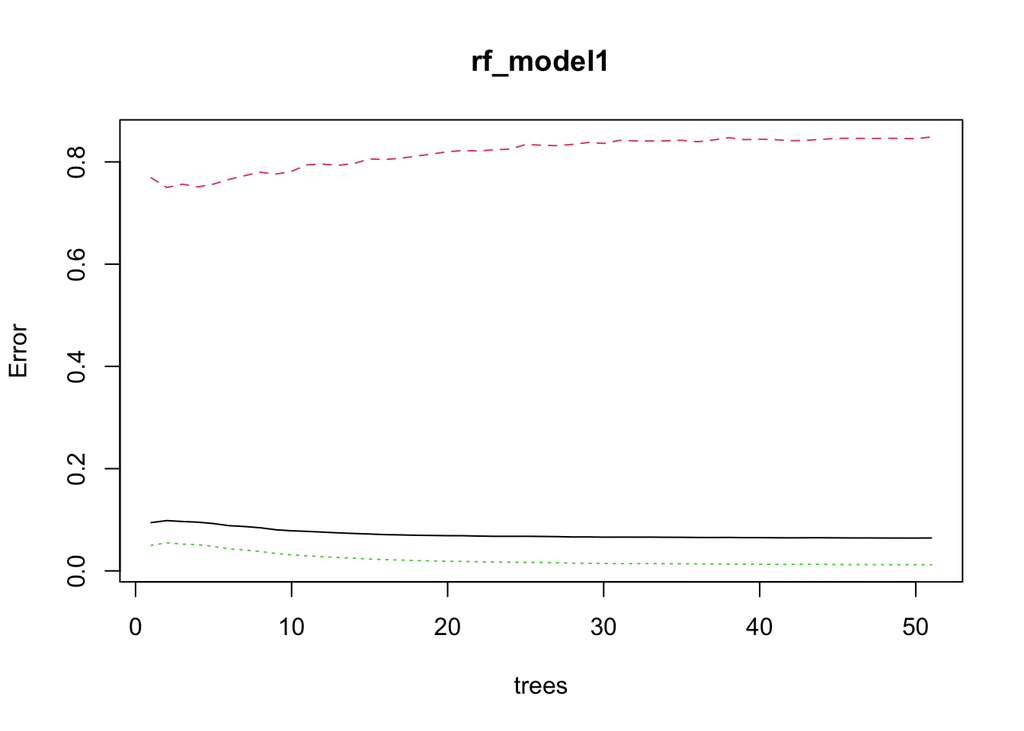

* The plot reveals that anything more than, say 25 trees, is really not that valuable.

```
##                                Defaulters Non_Defaulters MeanDecreaseAccuracy
## PercPremiumPaidbyCashCredit  0.0368410674   2.530236e-03         4.679708e-03
## Income                      -0.0071424892   1.176580e-02         1.058137e-02
## Count3to6monthsLate          0.0278845106   2.308527e-03         3.910656e-03
## Count6to12monthsLate         0.0554658214   5.732875e-03         8.845186e-03
## CountMoreThan12monthsLate    0.0189957933   2.827205e-03         3.840278e-03
## MaritalStatus               -0.0002905572  -4.105242e-05        -5.694654e-05
## VehOwned                     0.0004270653  -1.787021e-06         2.442311e-05
## NoofDep                      0.0002638030  -1.075531e-04        -8.404901e-05
## Accomodation                 0.0004282733  -3.983345e-05        -1.055306e-05
## riskScore                    0.0003476442   6.842720e-03         6.433535e-03
## NoofPremiumsPaid            -0.0032924634   6.645461e-03         6.023561e-03
## SourcingChannel             -0.0017769437   1.439836e-03         1.240519e-03
## ResidenceAreaType            0.0004842126  -4.517929e-05        -1.162410e-05
## premium                     -0.0076498690   6.702548e-03         5.804285e-03
## age                          0.0050920266   3.603835e-03         3.697725e-03
##                             MeanDecreaseGini
## PercPremiumPaidbyCashCredit        764.00132
## Income                             801.84985
## Count3to6monthsLate                234.04503
## Count6to12monthsLate               642.26444
## CountMoreThan12monthsLate          233.44346
## MaritalStatus                       42.88182
## VehOwned                            92.76106
## NoofDep                            127.66137
## Accomodation                        48.57406
## riskScore                          637.70528
## NoofPremiumsPaid                   363.47528
## SourcingChannel                    148.20150
## ResidenceAreaType                   46.08503
## premium                            272.48853
## age                                503.09787
```

### Random Forest Model 2

We will take ntree = 25 (odd number of trees are preferred)

```
## mtry = 3  OOB error = 6.36%
## Searching left ...
## mtry = 2     OOB error = 6.22%
## 0.02241255 1e-04
## mtry = 1     OOB error = 6.22%
## -0.0005035247 1e-04
## Searching right ...
## mtry = 6     OOB error = 6.58%
## -0.05866062 1e-04
```

[figure not shown]

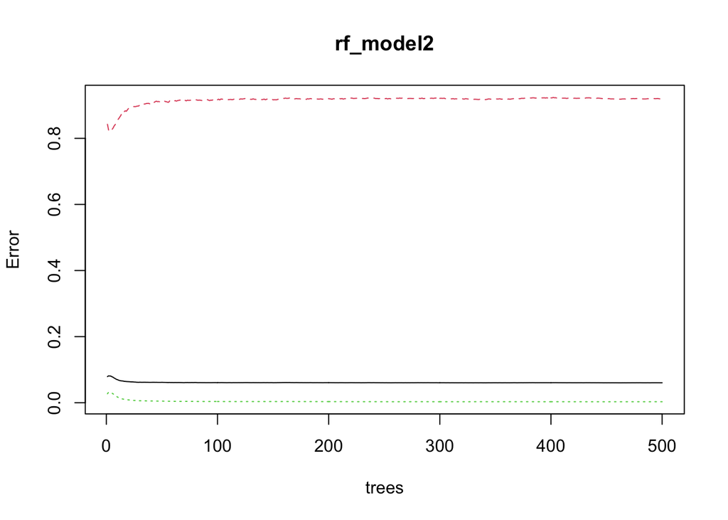

#### Model Validation

```
##                 train_predict.class_RF
##                  Defaulters Non_Defaulters
##   Defaulters            965           3034
##   Non_Defaulters          4          59880
```

```
## [1] 0.9524443
```

- The Train set has 95.24% accuracy
- The Train set shows a good collection on True Positives & False Negatives

#### Model Evaluation

```
##    test_predict.class_RF
##     Defaulters Non_Defaulters
##   1         69            930
##   2         49          14922
```

```
## [1] 0.9386976
```

- The Test set has 93.86% accuracy
- Both model show a good accuracy and dont overfit the data, but the true positive identification is better on the Train set.

#### Predict Default class and probability for Random Forest

#### Creating Confusion Matrix

```
##    rf_model1_predict_class
##     Defaulters Non_Defaulters
##   1        155            844
##   2        140          14831
```

```
##    rf_model2_predict_class
##     Defaulters Non_Defaulters
##   1         69            930
##   2         49          14922
```

Random Forest Model 1 is able to identify the defaulters more correctly than RF Model 2

#### Accuracy

```
## [1] 0.9383845
```

```
## [1] 0.9386976
```

#### Sensitivity of Model on Test Data

```
## [1] 0.9286788
```

```
## [1] 0.934377
```

#### Specificity of models on Test Data

```
## [1] 0.009705698
```

```
## [1] 0.004320601
```

#### Precision

#### KS

#### AUC

#### Gini

#### Concordance - Discordance

#### METRICS - Random Model 1 & 2

#### ROC Curves

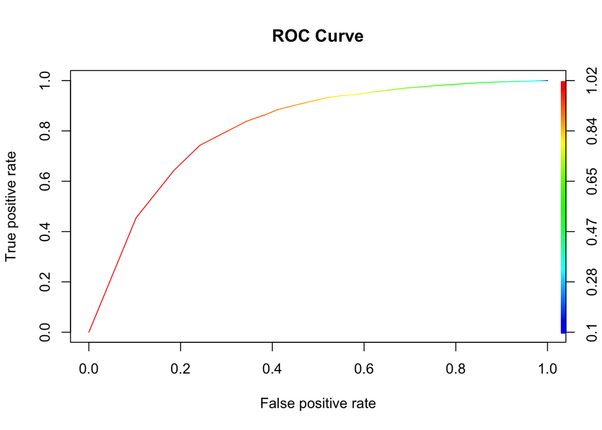

We see from the curve that we can reach ~0.9 tpr at fpr ~ 0.4. Let us check the probability cutoff at that point.

```
## Formal class 'performance' [package "ROCR"] with 6 slots
##   ..@ x.name      : chr "False positive rate"
##   ..@ y.name      : chr "True positive rate"
##   ..@ alpha.name  : chr "Cutoff"
##   ..@ x.values    :List of 1
##   .. ..$ : num [1:46] 0 0.103 0.185 0.242 0.304 ...
##   ..@ y.values    :List of 1
##   .. ..$ : num [1:46] 0 0.455 0.642 0.743 0.801 ...
##   ..@ alpha.values:List of 1
##   .. ..$ : num [1:46] Inf 1 0.98 0.961 0.941 ...
```

|  | cut | fpr | tpr |
| --- | --- | --- | --- |
| 1 | Inf | 0.00000000 | 0.0000000 |
| 2 | 1.000 | 0.01401401 | 0.1546323 |
| 3 | 0.998 | 0.04104104 | 0.3003139 |
| 4 | 0.996 | 0.05905906 | 0.4070536 |
| 5 | 0.994 | 0.07807808 | 0.4852715 |
| 6 | 0.992 | 0.09709710 | 0.5456549 |

Take fpr threshold = 0.4. Subset the dataframe cutoff to find the maximum tpr below this fpr threshold.

|  | cut | fpr | tpr |
| --- | --- | --- | --- |
| 38 | 0.928 | 0.3973974 | 0.8944626 |
| 37 | 0.930 | 0.3913914 | 0.8912564 |
| 36 | 0.932 | 0.3853854 | 0.8893194 |
| 35 | 0.934 | 0.3833834 | 0.8864471 |
| 34 | 0.936 | 0.3783784 | 0.8841761 |
| 33 | 0.938 | 0.3713714 | 0.8813706 |

#### New RF Model

```
##    class_prediction_with_new_cutoff
##         0     1
##   1   695   304
##   2  2975 11996
```

```
## [1] 0.7946775
```

```
## [1] 0.7511584
```

```
## [1] 0.0435191
```

### Model 6 : Gradient Boosting Machines

[figure not shown]

|  | var | rel.inf |
| --- | --- | --- |
| Count6to12monthsLate | Count6to12monthsLate | 40.60257537 |
| CountMoreThan12monthsLate | CountMoreThan12monthsLate | 16.74720432 |
| PercPremiumPaidbyCashCredit | PercPremiumPaidbyCashCredit | 16.33794049 |
| Count3to6monthsLate | Count3to6monthsLate | 15.43088245 |
| NoofPremiumsPaid | NoofPremiumsPaid | 3.40573741 |
| riskScore | riskScore | 3.06762183 |
| age | age | 2.06664933 |
| Income | Income | 1.01864690 |
| premium | premium | 0.56875958 |
| SourcingChannelB | SourcingChannelB | 0.16104759 |

[output cut: 8 more lines]

```
## Confusion Matrix and Statistics
##
##                 Reference
## Prediction       Defaulters Non_Defaulters
##   Defaulters            596            419
##   Non_Defaulters       3403          59465
##
##                Accuracy : 0.9402
##                  95% CI : (0.9383, 0.942)
##     No Information Rate : 0.9374
##     P-Value [Acc > NIR] : 0.001863
##
##                   Kappa : 0.2179
##
##  Mcnemar's Test P-Value : < 2.2e-16
##
##             Sensitivity : 0.14904
##             Specificity : 0.99300
##          Pos Pred Value : 0.58719
##          Neg Pred Value : 0.94587
##              Prevalence : 0.06260
##          Detection Rate : 0.00933
##    Detection Prevalence : 0.01589
##       Balanced Accuracy : 0.57102
##
##        'Positive' Class : Defaulters
##
```

#### Predict Default class and probability for Gradient Boost Model

#### Creating Confusion Matrix

```
##    gbm_model_predict_class
##     Defaulters Non_Defaulters
##   1        152            847
##   2        126          14845
```

#### Accuracy

```
## [1] 0.9390733
```

#### Sensitivity of Model on Test Data

```
## [1] 0.9295554
```

#### Specificity of models on Test Data

```
## [1] 0.009517846
```

#### Precision

```
## [1] 0.9295554
```

#### KS

#### AUC

#### Gini

#### Concordance - Discordance

#### METRICS - Gradient Boosting Model

```
## [1] 0.939073262 0.929555416 0.009517846 0.929555416          NA 0.828947577
## [7]          NA         NaN
```

### Model 7 : Xtreme Gradient boosting Machines

Predict using the trained model & check performance on test set

#### Predict Default class and probability for XG Boost

#### Creating Confusion Matrix

```
##    xgb_model_predict_class
##     Defaulters Non_Defaulters
##   1        113            886
##   2         81          14890
```

#### Accuracy

```
## [1] 0.939449
```

#### Sensitivity of Model on Test Data

```
## [1] 0.9323732
```

#### Specificity of models on Test Data

```
## [1] 0.007075767
```

#### Precision

#### KS

#### AUC

#### Gini

#### Concordance - Discordance

#### METRICS - XG Boost model

### MODELS COMPARISION

[output not shown]

## Interpreting the best model:

Having tried out various models and techniques, we have to realise the variables which are important from the perspective of the basic objective of the project i.e. **identifying upfront, the customers who have the propensity to default of their premium payments**.

1. The basic indicator for identifying on the defaulters would involve looking at the **Sensitivity** attributes of each model. **Sensitivity** identifies the true positive class who form the positive class - Defaulters.

2. **Confusion Matrix**

| Models | True Positive |
| --- | --- |
| CART Model1 | 176 |
| CART Model2 | 0 |
| Logistic Regression | 120 |
| Naive Bayes | 0 |
| KNN | 113 |
| RF Model1 | 155 |
| RF Model2 | 69 |
| Gradient Boost | 152 |
| XG Boost | 113 |

Looking for the models providing high True Positive / True Negativity, we identify **CART Model 1**, **Random Forest Model 1** & **Gradient Boost**.

3. **Accuracy** will tell us the proportion of the Defaulters & Non-Defaulters which also forms an important indicator while selecting the right model.

All the models are giving very high Accuracy score (above 93). Hence we can safely say all models qualify on the Accuracy threshold.

4. **Specificity** will highlight the non-defaulters, which will help us identify and go after the other cohort i.e. the Defaulters.

5. **AUC ROC** which is performance measurement for classification at various thresholds, ROC is a probability curve and AUC represents the degree or measure of separability. It tells how much the model is capable of distinguishing between the defaulters and non-defaulters. The higher the AUC, the better the performance of the model at distinguishing between the positive and negative classes

| Models | AUC |
| --- | --- |
| Cart Model 1 | 80 |
| RF Model 1 | 81 |
| KNN | 73 |
| Gradient Boost | 82 |
| XG Boost | 82 |

All the have a good AUC score

6. **Kolmogorov-Smirnov Test** will help us decide if the sample comes from a population with specific distribution. The p-value returned by the k-s test has the same interpretation as other p-values. You reject the null hypothesis that the two samples were drawn from the same distribution if the p-value is less than your significance level.

7. **GINI coefficient** which is measure of the distribution of defaulters across the population is a good indicator of inequality in the population. A level 0 would indicate all are same (equality) and as the numbers increase, so does the degree of inequality in the population.

[output not shown]

8. **Precision - Positive Predictive Value (PPV)** is the probability that customers identified with positive test as defaulters are truly defaulters, i.e. how often is a positive test represents true positive.

[output not shown]

Precision levels between Cart Model 1 & RF 1 would be of contention here as we need to deecide b etween these 2 models as they tick the boxes on most verticals.

**CONCLUSION**

**CART Model 1 & Random Forest Model 1**, both emerge as the better models to work upon.

- When we compare the efficiency of these two models, Random Forest has better predictive power and accuracy than a CART model because of random forest exhibit lower variance.
- Random Forest creates multiple CART trees based on “bootstrapped” samples of data and then combines the predictions. Also,Random Forest inherits properties of CART-like variable selection, missing values and outlier handling, nonlinear relationships, and variable interaction detection.

## Business Insights & Recommendations:

**Recommendations:**

- We need to keep in mind the current economic fallout due to the pandemic and the impact it has had on jobs/ business/income when we come our with solutions for the payments of the premiums. This could be in the lines of:
- Creating multiple options in paying premiums
- Multiple bouquets or sachet options for easy buy for specific plan or specific period
- Options to pay premiums at various time plans like bi-annual, quarterly, monthly etc. depending on the kind of customer we target to address.
- We could approach the insurance company to get some more information to further distill and identify the cohorts with reference to some information which may not be provided in the shared data. This could include information like Gender, Type of Insurance (purchased/ defaulted), frequency of the premiums to be paid, etc.

### Code Appendix

```r
knitr::opts_chunk$set(error = FALSE,     # suppress errors
                      message = FALSE,   # suppress messages
                      warning = FALSE,   # suppress warnings
                      echo = FALSE,      # suppress code
                      cache = TRUE)      # enable caching
library(ggplot2) # For graphs and visualisations
library(gridExtra) # To plot multiple ggplot graphs in a grid
library(DataExplorer) # To plot correlation plot between numerical variables
library(caTools) # Split Data into Test and Train Set
library(rpart) # To build CART decision tree
library(rattle) # To visualise decision tree
library(randomForest) # To build a Random Forest
library(ROCR) # To visualise the performance classifiers
library(ineq) # To calculate Gini
library(InformationValue) # For Concordance-Discordance
library(readxl) # to read excel file
library(dplyr) #provides a set of tools for efficiently manipulating datasets
library(caTools) # Split Data into Test and Train Set
library(caret) # for confusion matrix function
library(corrplot) # for a graphical display of a correlation matrix, confidence interval or general matrix.
library(randomForest) # to build a random forest model
library(rpart.plot) # to plot decision tree model
library(xgboost) # to build a XG Boost model
library(DMwR) # for SMOTE
library(naivebayes) # for implementation of the Naive Bayes
library(e1071) # to train SVM & obtain predictions from the model
library(mlr) # for a generic, object-oriented, and extensible framework
library(gbm) #For power-users with many variables
library(car) # use for multicollinearity test (i.e. Variance Inflation Factor(VIF))
library(MASS) # for step AIC
library(grid) # for the primitive graphical functions
library(ROCR) # To plot ROC-AUC curve
library(InformationValue) # for Concordance-Discordance
library(class) # to build a KNN model
library(knitr) # Necessary to generate sourcecodes from a .Rmd File
library(parallel)
library(ipred)
r <- mclapply(1:10, function(i) {
  Sys.sleep(10)  ## Do nothing for 10 seconds
}, mc.cores = 10)      ## Split this job across 10 cores
require("knitr")
opts_knit$set(root.dir = "/Users/rajeevnitnawre/Downloads/DSBA/Capstone Project - Insurance/Project 1/")
PremiumData= read_excel("Insurance Premium Default-Dataset.xlsx")
PremiumData <- PremiumData %>%
  mutate(age =  age_in_days/ 365.2425)
PremiumData$age=as.integer(PremiumData$age)
PremiumData$Income<- PremiumData$Income/1000
age=PremiumData$age
PremiumData$agegroup=cut(age,8,labels = c('1','2','3','4','5','6','7','8'))
PremiumData$age= round(as.numeric(PremiumData$age),0)
PremiumData = subset(PremiumData, select = -c(id,age_in_days))
dim(PremiumData)
names(PremiumData)[1]<-paste("PercPremiumPaidbyCashCredit")
names(PremiumData)[3]<-paste("Count3to6monthsLate")
names(PremiumData)[4]<-paste("Count6to12monthsLate")
names(PremiumData)[5]<-paste("CountMoreThan12monthsLate")
names(PremiumData)[11]<-paste("NoofPremiumsPaid")
names(PremiumData)[12]<-paste("SourcingChannel")
names(PremiumData)[13]<-paste("ResidenceAreaType")
names(PremiumData)[7]<-paste("VehOwned")
names(PremiumData)[8]<-paste("NoofDep")
names(PremiumData)[10]<-paste("riskScore")
names(PremiumData)[6]<-paste("MaritalStatus")
  outlier_treatment_fun_age = function(PremiumData,age){
  capping = as.vector(quantile(PremiumData[,age],0.99))
  flooring = as.vector(quantile(PremiumData[,age],0.01))
  PremiumData[,age][which(PremiumData[,age]<flooring)]= flooring
  PremiumData[,age][which(PremiumData[,age]>capping)]= capping
  #print(’done’,var_name)
  return(PremiumData)
}
new_vars = c('age','Income','premium','NoofPremiumsPaid','PercPremiumPaidbyCashCredit',
             'Count3to6monthsLate','Count6to12monthsLate','CountMoreThan12monthsLate')
outlier_treatment_fun_Income = function(PremiumData,Income){
  capping = as.vector(quantile(PremiumData[,Income],0.99))
  flooring = as.vector(quantile(PremiumData[,Income],0.01))
  PremiumData[,Income][which(PremiumData[,Income]<flooring)]= flooring
  PremiumData[,Income][which(PremiumData[,Income]>capping)]= capping
  #print(’done’,var_name)
  return(PremiumData)
}
outlier_treatment_fun_Premium = function(PremiumData,premium){
  capping = as.vector(quantile(PremiumData[,premium],0.99))
  flooring = as.vector(quantile(PremiumData[,premium],0.01))
  PremiumData[,premium][which(PremiumData[,premium]<flooring)]= flooring
  PremiumData[,premium][which(PremiumData[,premium]>capping)]= capping
  #print(’done’,var_name)
  return(PremiumData)
}
outlier_treatment_fun_No_Premium = function(PremiumData,NoofPremiumsPaid){
  capping = as.vector(quantile(PremiumData[,NoofPremiumsPaid],0.99))
  flooring = as.vector(quantile(PremiumData[,NoofPremiumsPaid],0.01))
  PremiumData[,NoofPremiumsPaid][which(PremiumData[,NoofPremiumsPaid]<flooring)]= flooring
  PremiumData[,NoofPremiumsPaid][which(PremiumData[,NoofPremiumsPaid]>capping)]= capping
  #print(’done’,var_name)
  return(PremiumData)
}
outlier_treatment_fun_No_Premium = function(PremiumData,PercPremiumPaidbyCashCredit){
  capping = as.vector(quantile(PremiumData[,PercPremiumPaidbyCashCredit],0.99))
  flooring = as.vector(quantile(PremiumData[,PercPremiumPaidbyCashCredit],0.01))
  PremiumData[,PercPremiumPaidbyCashCredit][which(PremiumData[,PercPremiumPaidbyCashCredit]<flooring)]= flooring
  PremiumData[,PercPremiumPaidbyCashCredit][which(PremiumData[,PercPremiumPaidbyCashCredit]>capping)]= capping
  #print(’done’,var_name)
  return(PremiumData)
}
 outlier_treatment_fun_3to6 = function(PremiumData,Count3to6monthsLate){
  capping = as.vector(quantile(PremiumData[,Count3to6monthsLate],0.99))
  flooring = as.vector(quantile(PremiumData[,Count3to6monthsLate],0.01))
  PremiumData[,Count3to6monthsLate][which(PremiumData[,Count3to6monthsLate-months_late]<flooring)]= flooring
  PremiumData[,Count3to6monthsLate][which(PremiumData[,Count3to6monthsLate-months_late]>capping)]= capping
  #print(’done’,var_name)
  return(PremiumData)
}
 outlier_treatment_fun_6to12 = function(PremiumData,Count6to12monthsLate){
  capping = as.vector(quantile(PremiumData[,Count6to12monthsLate],0.99))
  flooring = as.vector(quantile(PremiumData[,Count6to12monthsLate],0.01))
  PremiumData[,Count6to12monthsLate][which(PremiumData[,Count6to12monthsLate]<flooring)]= flooring
  PremiumData[,Count6to12monthsLate][which(PremiumData[,Count6to12monthsLate]>capping)]= capping
  #print(’done’,var_name)
  return(PremiumData)
}
 outlier_treatment_fun_ = function(PremiumData,CountMoreThan12monthsLate){
  capping = as.vector(quantile(PremiumData[,CountMoreThan12monthsLate],0.99))
  flooring = as.vector(quantile(PremiumData[,CountMoreThan12monthsLate],0.01))
  PremiumData[,CountMoreThan12monthsLate][which(PremiumData[,CountMoreThan12monthsLate]<flooring)]= flooring
  PremiumData[,CountMoreThan12monthsLate][which(PremiumData[,CountMoreThan12monthsLate]>capping)]= capping
  #print(’done’,var_name)
  return(PremiumData)
}
Num_subset_PremiumData= PremiumData[, c("age","Income","riskScore","premium",
                                    "PercPremiumPaidbyCashCredit","Count3to6monthsLate",
                                    "Count6to12monthsLate","CountMoreThan12monthsLate",
                                    "NoofPremiumsPaid")]
Num_subset_PremiumData$default<-PremiumData$default
highCorr <- findCorrelation(cor(Num_subset_PremiumData[,-10]), cutoff = 0.7)
```

```r
PremiumData$default<- as.factor(PremiumData$default)
levels(PremiumData$default) <- c("Defaulters", "Non_Defaulters")
PremiumData$default <- relevel(PremiumData$default, ref = "Defaulters") # Reference class : Defaulter
levels(PremiumData$default)
PremiumData=PremiumData[,-17]
new_vars = c('age','Income','premium','NoofPremiumsPaid','PercPremiumPaidbyCashCredit',
             'Count3to6monthsLate','Count6to12monthsLate','CountMoreThan12monthsLate')

correlations = cor(PremiumData[,new_vars])

col1 <- colorRampPalette(c("#7F0000", "red", "#FF7F00", "yellow", "#7FFF7F",
                           "cyan", "#007FFF"))
corrplot(correlations,number.cex = 1,method = 'number',type = 'lower',col = col1(100))
set.seed(123)

trainIndex <- createDataPartition(PremiumData$default, p = .80, list = FALSE)

PremiumData_Train <- PremiumData[ trainIndex,]
PremiumData_Test  <- PremiumData[-trainIndex,]

prop.table(table(PremiumData_Train$default))*100
prop.table(table(PremiumData_Test$default))*100
prop.table(table(PremiumData$default))*100
rm(PremiumData)
rm(Num_subset_PremiumData)

table(PremiumData_Train$default)
prop.table(table(PremiumData_Train$default))

PremiumData_Train <- as.data.frame(PremiumData_Train)
PremiumData_Train$default <- as.factor(PremiumData_Train$default)


smote_train <- SMOTE(default ~ ., data  = PremiumData_Train[,c(-12,-13)],
                     perc.over = 3700,
                     perc.under = 300
                    )

prop.table(table(smote_train$default))*100
table(smote_train$default)
fitControl <- trainControl(
  method = 'repeatedcv',           # k-fold cross validation
  number = 5,                     # number of folds or k
  repeats = 1,                     # repeated k-fold cross-validation
  allowParallel = TRUE,
  classProbs = TRUE,
  summaryFunction=twoClassSummary# should class probabilities be returned
)
r.ctrl = rpart.control(minsplit = 50, minbucket = 10, cp = 0, xval = 10)
cart_model1 <- rpart(formula = default~., data = PremiumData_Train, method = "class", control = r.ctrl)
printcp(cart_model1)
plotcp(cart_model1)
cart_model2 = prune(cart_model1, cp= 0.062 ,"CP")
printcp(cart_model2)
cart_model2
cart_model1$variable.importance
# Variable importance is generally computed based on the corresponding reduction of predictive accuracy
# when the predictor of interest is removed.
# Predicting on the train dataset
train_predict.class_CART <- predict(cart_model2, PremiumData_Train, type="class") # Predicted Classes
train_predict.score_CART <- predict(cart_model2, PremiumData_Train) # Predicted Probabilities

# Create confusion matrix for train data predictions
tab.train_CART = table(PremiumData_Train$default, train_predict.class_CART)
tab.train_CART

# Accuracy on train data
accuracy.train_CART = sum(diag(tab.train_CART)) / sum(tab.train_CART)
accuracy.train_CART
# Predicting on the test dataset
test_predict.class_CART <- predict(cart_model2, PremiumData_Test, type="class") # Predicted Classes
test_predict.score_CART <- predict(cart_model2, PremiumData_Test) # Predicted Probabilities

# Create confusion matrix for test data predictions
tab.test_CART = table(PremiumData_Test$default, test_predict.class_CART)
tab.test_CART

# Accuracy on test data
accuracy.test_CART = sum(diag(tab.test_CART)) / sum(tab.test_CART)
accuracy.test_CART

# Predict on test data using cart_model1
cart_model1_predict_class = predict(cart_model1, PremiumData_Test, type = 'class')
cart_model1_predict_score = predict(cart_model1, PremiumData_Test, type = 'prob')

# Predict on test data using cart_model2
cart_model2_predict_class = predict(cart_model2, PremiumData_Test, type = 'class')
cart_model2_predict_score = predict(cart_model2, PremiumData_Test, type = 'prob')
#Confusion Matrix of Cart_Model1
conf_mat_cart_model1 = table(PremiumData_Test$default, cart_model1_predict_class)
conf_mat_cart_model1

#Confusion Matrix of Cart_Model2
conf_mat_cart_model2 = table(PremiumData_Test$default, cart_model2_predict_class)
conf_mat_cart_model2
# Accuracy of cart Model 1
accuracy_cart_model1 = sum(diag(conf_mat_cart_model1)) / sum(conf_mat_cart_model1)
accuracy_cart_model1

# Accuracy of cart Model 2
accuracy_cart_model2 = sum(diag(conf_mat_cart_model2)) / sum(conf_mat_cart_model2)
accuracy_cart_model2
# Sensitivity of Cart Model1
sensitivity_cart_model1 = conf_mat_cart_model1[2,2] / sum(conf_mat_cart_model1)
sensitivity_cart_model1
# Sensitivity of Cart Model2
sensitivity_cart_model2 = conf_mat_cart_model2[2,2] / sum(conf_mat_cart_model2)
sensitivity_cart_model2
# Specificity of Cart Model 1
specificity_cart_model1 = conf_mat_cart_model1[1,1] / sum(conf_mat_cart_model1)
specificity_cart_model1
# Specificity of Cart Model 2
specificity_cart_model2 = conf_mat_cart_model2[1,1] / sum(conf_mat_cart_model2)
specificity_cart_model2
# Precision of Cart Model 1
precision_cart_model1 = conf_mat_cart_model1[2,2] / sum(conf_mat_cart_model1[,'Defaulters'])
precision_cart_model1

# Precision of Cart Model 2
precision_cart_model2 = conf_mat_cart_model2[2,2] / sum(conf_mat_cart_model2[,'Defaulters'])
precision_cart_model2
# Using library ROCR functions prediction and performance
library(ROCR)
# KS of Cart Model 1
pred_cart_model1 = prediction(cart_model1_predict_score[, 2], PremiumData_Test$default)
perf_cart_model1 = ROCR::performance(pred_cart_model1,"tpr","fpr")
ks_cart_model1 = max(attr(perf_cart_model1,'y.values')[[1]] - attr(perf_cart_model1,'x.values')[[1]])

pred_cart_model2 = prediction(cart_model2_predict_score[, 2], PremiumData_Test$default)
perf_cart_model2 = ROCR::performance(pred_cart_model2,"tpr","fpr")
ks_cart_model2 = max(attr(perf_cart_model2,'y.values')[[1]] - attr(perf_cart_model2,'x.values')[[1]])
# Using library ROCR
auc_cart_model1 = ROCR::performance(pred_cart_model1, measure = "auc")
auc_cart_model1 = auc_cart_model1@y.values[[1]]

auc_cart_model2 = ROCR::performance(pred_cart_model2, measure = "auc")
auc_cart_model2 = auc_cart_model2@y.values[[1]]
library(ineq)

#Gini of Cart Model 1
gini_cart_model1 = ineq(cart_model1_predict_score[, 2],"gini")
```

```r
#Gini of Cart Model 2
gini_cart_model2 = ineq(cart_model2_predict_score[, 2],"gini")
#Concordance of Cart Model 1
concordance_cart_model1 = Concordance(actuals = ifelse(PremiumData_Test$default == 'Defaulters', 1,0), predictedScores = ifelse(cart_model1_predict_class == 'Defaulters', 1,0))

#Concordance of Cart Model 2
concordance_cart_model2 = Concordance(actuals = ifelse(PremiumData_Test$default == 'Defaulters', 1,0), predictedScores = ifelse(cart_model2_predict_class == 'Defaulters', 1,0))
cart_model1_metrics = c(accuracy_cart_model1, sensitivity_cart_model1, specificity_cart_model1, precision_cart_model1, ks_cart_model1, auc_cart_model1, gini_cart_model1, concordance_cart_model1$Concordance)

cart_model2_metrics = c(accuracy_cart_model2, sensitivity_cart_model2, specificity_cart_model2, precision_cart_model2, ks_cart_model2, auc_cart_model2, gini_cart_model2, concordance_cart_model2$Concordance)
PremiumData_Train$default<- as.factor(PremiumData_Train$default)
PremiumData_Test$default<- as.factor(PremiumData_Test$default)
lrmod <- caret::train(default ~ .,
                      method     = "glm",
                      metric     = "Sensitivity",
                      data       = PremiumData_Train)


lrpred<-predict(lrmod,newdata=PremiumData_Test)

lrpred=as.numeric(lrpred)
PremiumData_Test$default=as.numeric(PremiumData_Test$default)
confusionMatrix(table(lrpred,PremiumData_Test$default))

caret::varImp(lrmod)
#Predict on test data using Logistic Regression Model
lrmod_predict_class = predict(lrmod, PremiumData_Test, type = 'raw')
lrmod_predict_score = predict(lrmod, PremiumData_Test, type = 'prob')
#Confusion Matrix of Logistic Regression Model
conf_mat_lrmod = table(PremiumData_Test$default, lrmod_predict_class)
conf_mat_lrmod

# Accuracy of Logistic Regression Model
accuracy_lrmod = sum(diag(conf_mat_lrmod)) / sum(conf_mat_lrmod)
accuracy_lrmod
# Sensitivity of Logistic Regression Model
sensitivity_lrmod = conf_mat_lrmod[2,2]/ sum(conf_mat_lrmod)
sensitivity_lrmod
# Specificity of Logistic Regression Model
specificity_lrmod = conf_mat_lrmod[1,1] / sum(conf_mat_lrmod)
specificity_lrmod
# Precision of Logistic Regression Model
precision_lrmod = conf_mat_lrmod[2,2] / sum(conf_mat_lrmod[,'Defaulters'])
precision_lrmod
# Using library ROCR functions prediction and performance
library(ROCR)
# KS of Logistic Regression
pred_lrmod = prediction(lrmod_predict_score[, 2], PremiumData_Test$default)
perf_lrmod = ROCR::performance(pred_lrmod,"tpr","fpr")
ks_lrmod = max(attr(perf_lrmod,'y.values')[[1]] - attr(perf_lrmod,'x.values')[[1]])
# Using library ROCR
auc_lrmod = ROCR::performance(pred_lrmod, measure = "auc")
auc_lrmod = NA
library(ineq)
#Gini of Logistic Regression Model
gini_lrmod = ineq(lrmod_predict_score[, 2],"gini")
#Concordance of Logistic Regression Model
concordance_lrmod = Concordance(actuals = ifelse(PremiumData_Test$default == 'Defaulters', 1,0),
                                   predictedScores = ifelse(lrmod_predict_class == 'Defaulters', 1,0))
lrmod_metrics = c(accuracy_lrmod, sensitivity_lrmod, specificity_lrmod, precision_lrmod,
ks_lrmod, auc_lrmod, gini_lrmod, concordance_lrmod$Concordance)
PremiumData_Train$default<- as.factor(PremiumData_Train$default)
PremiumData_Test$default<- as.factor(PremiumData_Test$default)
model_nb <- caret::train(default ~ ., data = PremiumData_Train,
                         method = "naive_bayes")

summary(model_nb)
nb_predictions_test <- predict(model_nb, newdata = PremiumData_Test, type = "raw")
nb_predictions_test=as.numeric(nb_predictions_test)
PremiumData_Test$default=as.numeric(PremiumData_Test$default)

confusionMatrix(table(nb_predictions_test,PremiumData_Test$default))
#Predict on test data using Logistic Regression Model
model_nb_predict_class = predict(model_nb, PremiumData_Test, type = 'raw')
model_nb_predict_score = predict(model_nb, PremiumData_Test, type = 'prob')
#Confusion Matrix of Logistic Regression Model
conf_mat_model_nb = table(PremiumData_Test$default, model_nb_predict_class)
conf_mat_model_nb

# Accuracy of Naive Bayes Model
accuracy_model_nb = sum(diag(conf_mat_model_nb)) / sum(conf_mat_model_nb)
accuracy_model_nb
# Sensitivity of Naive Bayes Model
sensitivity_model_nb = conf_mat_model_nb[2,2]/ sum(conf_mat_model_nb)
sensitivity_model_nb
# Specificity of LNaive Bayes Model
specificity_model_nb = conf_mat_model_nb[1,1] / sum(conf_mat_model_nb)
specificity_model_nb
# Precision of Naive Bayes Model
precision_model_nb = conf_mat_model_nb[2,2] / sum(conf_mat_model_nb[,'Defaulters'])
precision_model_nb
# Using library ROCR functions prediction and performance
library(ROCR)
# KS of Naive Bayes
pred_model_nb = prediction(model_nb_predict_score[, 2], PremiumData_Test$default)
perf_model_nb = ROCR::performance(pred_model_nb,"tpr","fpr")
ks_model_nb = max(attr(perf_model_nb,'y.values')[[1]] - attr(perf_model_nb,'x.values')[[1]])
# Using library ROCR
auc_model_nb = ROCR::performance(pred_model_nb, measure = "auc")
auc_model_nb = NA
library(ineq)
#Gini of Naive Bayes Model
gini_model_nb = ineq(model_nb_predict_score[, 2],"gini")
#Concordance of Naive Bayes Model
concordance_model_nb = Concordance(actuals = ifelse(PremiumData_Test$default == 'Defaulters', 1,0),
                                   predictedScores = ifelse(model_nb_predict_class == 'Defaulters', 1,0))
model_nb_metrics = c(accuracy_model_nb, sensitivity_model_nb, specificity_model_nb, precision_model_nb,
ks_model_nb, auc_model_nb, gini_model_nb, concordance_model_nb$Concordance)
set.seed(123)
knn_model <- caret::train(default ~ ., data = PremiumData_Train,
                          preProcess = c("center", "scale"),
                          method = "knn",
                          tuneLength = 3,
                          trControl = fitControl)
knn_model


knn_predictions_test <- predict(knn_model, newdata = PremiumData_Test, type = "raw")
#confusionMatrix(knn_predictions_test, PremiumData_Test$default)

#Predict on test data using KNN Model
knn_model_predict_class = predict(knn_model, PremiumData_Test, type = 'raw')
knn_model_predict_score = predict(knn_model, PremiumData_Test, type = 'prob')
#Confusion Matrix of KNN Model
conf_mat_knn_model = table(PremiumData_Test$default, knn_model_predict_class)
conf_mat_knn_model
# Accuracy of KNN Model
accuracy_knn_model = sum(diag(conf_mat_knn_model)) / sum(conf_mat_knn_model)
accuracy_knn_model
# Sensitivity of KNN Model
sensitivity_knn_model = conf_mat_knn_model[2,2]/ sum(conf_mat_knn_model)
sensitivity_knn_model
# Specificity of KNN Model
specificity_knn_model = conf_mat_knn_model[1,1] / sum(conf_mat_knn_model)
specificity_knn_model
# Precision of KNN Model
precision_knn_model = conf_mat_knn_model[2,2] / sum(conf_mat_knn_model[,'Defaulters'])
precision_knn_model
# Using library ROCR functions prediction and performance
library(ROCR)
```

```r
# KS of KNN Model
pred_knn_model = prediction(knn_model_predict_score[, 2], PremiumData_Test$default)
perf_knn_model = ROCR::performance(pred_knn_model,"tpr","fpr")
ks_knn_model = max(attr(perf_knn_model,'y.values')[[1]] - attr(perf_knn_model,'x.values')[[1]])
# Using library ROCR
auc_knn_model = ROCR::performance(pred_knn_model, measure = "auc")
auc_knn_model = auc_knn_model@y.values[[1]]
library(ineq)
#Gini of KNN Model
gini_knn_model = ineq(knn_model_predict_score[, 2],"gini")
#Concordance of KNN Model
concordance_knn_model = Concordance(actuals = ifelse(PremiumData_Test$default == 'Defaulters', 1,0),
                                      predictedScores = ifelse(knn_model_predict_class == 'Defaulters', 1,0))
knn_model_metrics = c(accuracy_knn_model, sensitivity_knn_model, specificity_knn_model, precision_knn_model,
ks_knn_model, auc_knn_model, gini_knn_model, concordance_knn_model$Concordance)

set.seed(1000)
par(mar=c(1,1,1,1))

PremiumData_Train$default=as.factor(PremiumData_Train$default)
PremiumData_Test$default=as.factor(PremiumData_Test$default)
rf_model1 = randomForest(
  default ~ .,
  data = PremiumData_Train,
  ntree = 51,
  mtry = 10,
  nodesize = 10,
  importance = TRUE
)
print(rf_model1)
plot(rf_model1)
print(rf_model1$importance)
set.seed(1000) # To ensure reproducibility
par(mar=c(1,1,1,1))
rf_model2 = tuneRF(x = PremiumData_Train[, -15], # matrix or data frame of predictor/independent variables
                   y = PremiumData_Train$default, # response vector (factor for classification, numeric for regression)
                   mtrystart = 5, # starting value of mtry
                   stepfactor=1.5, # at each iteration, mtry is inflated (or deflated) by this value
                   ntree=25, # number of trees built for each mtry value
                   improve=0.0001, # the (relative) improvement in OOB error must be by this much for the search to continue
                   nodesize=10, # Minimum size of terminal nodes
                   trace=TRUE, # prints the progress of the search
                   plot=TRUE,
                   doBest=TRUE, # return a forest using the optimal mtry found
                   importance=TRUE #
)
plot(rf_model2)
# Predicting on the train dataset
train_predict.class_RF <- predict(rf_model2, PremiumData_Train, type="class") # Predicted Classes
train_predict.score_RF <- predict(rf_model2, PremiumData_Train, type = 'prob') # Predicted Probabilities

# Create confusion matrix for train data predictions
tab.train_RF = table(PremiumData_Train$default, train_predict.class_RF)
tab.train_RF

# Accuracy on train data
accuracy.train_RF = sum(diag(tab.train_RF)) / sum(tab.train_RF)
accuracy.train_RF
# Predicting on the test dataset
test_predict.class_RF <- predict(rf_model2, PremiumData_Test, type="class") # Predicted Classes
test_predict.score_RF <- predict(rf_model2, PremiumData_Test, type = 'prob') # Predicted Probabilities

# Create confusion matrix for test data predictions
tab.test_RF = table(PremiumData_Test$default, test_predict.class_RF)
tab.test_RF

# Accuracy on test data
accuracy.test_RF = sum(diag(tab.test_RF)) / sum(tab.test_RF)
accuracy.test_RF

# Predict on test data using rf_model1
rf_model1_predict_class = predict(rf_model1, PremiumData_Test, type = 'class')
rf_model1_predict_score = predict(rf_model1, PremiumData_Test, type = 'prob')

# Predict on test data using rf_model2
rf_model2_predict_class = predict(rf_model2, PremiumData_Test, type = 'class')
rf_model2_predict_score = predict(rf_model2, PremiumData_Test, type = 'prob')
#Confusion Matrix of Random Forest Model 1
conf_mat_rf_model1 = table(PremiumData_Test$default, rf_model1_predict_class)
conf_mat_rf_model1

#Confusion Matrix of Random Forest Model 2
conf_mat_rf_model2 = table(PremiumData_Test$default, rf_model2_predict_class)
conf_mat_rf_model2
# Accuracy of RF Model 1
accuracy_rf_model1 = sum(diag(conf_mat_rf_model1)) / sum(conf_mat_rf_model1)
accuracy_rf_model1
# Accuracy of RF Model 1
accuracy_rf_model2 = sum(diag(conf_mat_rf_model2)) / sum(conf_mat_rf_model2)
accuracy_rf_model2
# Sensitivity of RF Model1
sensitivity_rf_model1 = conf_mat_rf_model1[2,2] / sum(conf_mat_rf_model1)
sensitivity_rf_model1
# Sensitivity of RF Model2
sensitivity_rf_model2 = conf_mat_rf_model2[2,2] / sum(conf_mat_rf_model2)
sensitivity_rf_model2
# Specificity of RF Model 1
specificity_rf_model1 = conf_mat_rf_model1[1,1] / sum(conf_mat_rf_model1)
specificity_rf_model1
# Specificity of RF Model
specificity_rf_model2 = conf_mat_rf_model2[1,1] / sum(conf_mat_rf_model2)
specificity_rf_model2
# Precision of RF Model 1
precision_rf_model1 = conf_mat_rf_model1[2,2] / sum(conf_mat_rf_model1[,'Defaulters'])

# Precision of RF Model 2
precision_rf_model2 = conf_mat_rf_model2[2,2] / sum(conf_mat_rf_model2[,'Defaulters'])
# Using library ROCR functions prediction and performance
library(ROCR)
# KS of RF Model 1
pred_rf_model1 = prediction(rf_model1_predict_score[, 2], PremiumData_Test$default)
perf_rf_model1 = ROCR::performance(pred_rf_model1,"tpr","fpr")
ks_rf_model1 = max(attr(perf_rf_model1,'y.values')[[1]] - attr(perf_rf_model1,'x.values')[[1]])

pred_rf_model2 = prediction(rf_model2_predict_score[, 2], PremiumData_Test$default)
perf_rf_model2 = ROCR::performance(pred_rf_model2,"tpr","fpr")
ks_rf_model2 = max(attr(perf_rf_model2,'y.values')[[1]] - attr(perf_rf_model2,'x.values')[[1]])
# Using library ROCR
auc_rf_model1 = ROCR::performance(pred_rf_model1, measure = "auc")
auc_rf_model1 = auc_rf_model1@y.values[[1]]

auc_rf_model2 = ROCR::performance(pred_rf_model2, measure = "auc")
auc_rf_model2 = auc_rf_model2@y.values[[1]]
library(ineq)
#Gini of RF Model 1
gini_rf_model1 = ineq(rf_model1_predict_score[, 2],"gini")

#Gini of RF Model 2
gini_rf_model2 = ineq(rf_model2_predict_score[, 2],"gini")
#Concordance of RF Model 1
concordance_rf_model1 = Concordance(actuals = ifelse(PremiumData_Test$default == 'Defaulters', 1,0), predictedScores = ifelse(rf_model1_predict_class == 'Defaulters', 1,0))

#Concordance of RF Model 2
concordance_rf_model2 = Concordance(actuals = ifelse(PremiumData_Test$default == 'Defaulters', 1,0), predictedScores = ifelse(rf_model2_predict_class == 'Defaulters', 1,0))
rf_model1_metrics = c(accuracy_rf_model1, sensitivity_rf_model1, specificity_rf_model1, precision_rf_model1, ks_rf_model1, auc_rf_model1, gini_rf_model1, concordance_rf_model1$Concordance)
```

```r
rf_model2_metrics = c(accuracy_rf_model2, sensitivity_rf_model2, specificity_rf_model2, precision_rf_model2, ks_rf_model2, auc_rf_model2, gini_rf_model2, concordance_rf_model2$Concordance)
pred_rf_model1 = prediction(rf_model1_predict_score[, 2], PremiumData_Test$default)
perf_rf_model1 = ROCR::performance(pred_rf_model1,"tpr","fpr")
plot(perf_rf_model1, main = "ROC Curve" ,colorize = TRUE)
str(perf_rf_model1)

cutoffs <-
  data.frame(
  cut = perf_rf_model2@alpha.values[[1]],
  fpr = perf_rf_model2@x.values[[1]],
  tpr = perf_rf_model2@y.values[[1]]
  )

head(cutoffs)
View(cutoffs)
cutoffs <- cutoffs[order(cutoffs$tpr, decreasing=TRUE),]
head(subset(cutoffs, fpr < 0.4))
class_prediction_with_new_cutoff = ifelse(rf_model1_predict_score[, 2] >= 0.934, 1, 0)
new_confusion_matrix = table(PremiumData_Test$default, class_prediction_with_new_cutoff)
new_confusion_matrix

new_accuracy = sum(diag(new_confusion_matrix)) / sum(new_confusion_matrix)
new_accuracy

new_sensitivity = new_confusion_matrix[2,2] / sum(new_confusion_matrix)
new_sensitivity

new_specificity = new_confusion_matrix[1,1] / sum(new_confusion_matrix)
new_specificity

rfnew_model_metrics = c(new_accuracy, new_sensitivity, new_specificity, NA , NA, NA, NA, NA)
gbm_model <- caret::train(default ~ ., data = PremiumData_Train,
                          method = "gbm",
                          trControl = fitControl,
                          verbose = FALSE)

summary(gbm_model)
gbm_predictions_test <- predict(gbm_model, newdata = PremiumData_Train, type = "raw")
confusionMatrix(gbm_predictions_test, PremiumData_Train$default)
#Predict on test data using Logistic Regression Model
gbm_model_predict_class = predict(gbm_model, PremiumData_Test, type = 'raw')
gbm_model_predict_score = predict(gbm_model, PremiumData_Test, type = 'prob')
#Confusion Matrix of Gradient Boosting Model
conf_mat_gbm_model = table(PremiumData_Test$default, gbm_model_predict_class)
conf_mat_gbm_model
# Accuracy of Gradient Boosting Model
accuracy_gbm_model = sum(diag(conf_mat_gbm_model)) / sum(conf_mat_gbm_model)
accuracy_gbm_model
# Sensitivity of Gradient Boosting Model
sensitivity_gbm_model = conf_mat_gbm_model[2,2]/ sum(conf_mat_gbm_model)
sensitivity_gbm_model
# Specificity of Gradient Boosting Model
specificity_gbm_model = conf_mat_gbm_model[1,1] / sum(conf_mat_gbm_model)
specificity_gbm_model
# Precision of Gradient Boosting Model
precision_gbm_model = conf_mat_gbm_model[2,2] / sum(conf_mat_gbm_model)
precision_gbm_model
# Using library ROCR functions prediction and performance
library(ROCR)
# KS of Gradient Boosting
#pred_gbm_model = prediction(gbm_model_predict_score[, 1000], PremiumData_Test$default)
#perf_gbm_model = ROCR::performance(pred_gbm_model,"tpr","fpr")
#ks_gbm_model = max(attr(perf_gbm_model,'y.values')[[1]] - attr(perf_gbm_model,'x.values')[[1]])
ks_gbm_model = NA
# Using library ROCR
auc_gbm_model = ROCR::performance(pred_model_nb, measure = "auc")
auc_gbm_model = auc_gbm_model@y.values[[1]]
library(ineq)
#Gini of Gradient Boosting Model
#gini_gbm_model = ineq(gbm_model_predict_score[, 2],"gini")
gini_gbm_model=NA
#Concordance of Gradient Boosting Model
concordance_gbm_model = Concordance(actuals = ifelse(PremiumData_Test$default == 'Defaulters', 1,0),
                                   predictedScores = ifelse(gbm_model_predict_class == 'Defaulters', 1,0))
gbm_model_metrics = c(accuracy_gbm_model, sensitivity_gbm_model, specificity_gbm_model, precision_gbm_model,
ks_gbm_model, auc_gbm_model, gini_gbm_model, concordance_gbm_model$Concordance)
gbm_model_metrics
cv.ctrl <- trainControl(method = "repeatedcv", repeats = 1,number = 3,
                        summaryFunction = twoClassSummary,
                        classProbs = TRUE,
                        allowParallel=T)

xgb.grid <- expand.grid(nrounds = 100,
                        eta = c(0.01),
                        max_depth = c(2,4),
                        gamma = 0,               #default=0
                        colsample_bytree = 1,    #default=1
                        min_child_weight = 1,    #default=1
                        subsample = 1            #default=1
)

xgb_model <- caret::train(default~.,
                          data=PremiumData_Train,
                          method="xgbTree",
                          trControl=cv.ctrl,
                          tuneGrid=xgb.grid,
                          verbose=T,
                          nthread = 2
)

xgb_predictions_test <- predict(xgb_model, newdata = PremiumData_Test, type = "raw")
#confusionMatrix(xgb_predictions_test, PremiumData_Test$default)
#Predict on test data using XG Boost Model
xgb_model_predict_class = predict(xgb_model, PremiumData_Test, type = 'raw')
xgb_model_predict_score = predict(xgb_model, PremiumData_Test, type = 'prob')
#Confusion Matrix of XG Boost Model
conf_mat_xgb_model = table(PremiumData_Test$default, xgb_model_predict_class)
conf_mat_xgb_model

# Accuracy of XG Boost Model
accuracy_xgb_model = sum(diag(conf_mat_xgb_model)) / sum(conf_mat_xgb_model)
accuracy_xgb_model
# Sensitivity of XG Boost Model
sensitivity_xgb_model = conf_mat_xgb_model[2,2]/ sum(conf_mat_xgb_model)
sensitivity_xgb_model
# Specificity of XG Boost Model
specificity_xgb_model = conf_mat_xgb_model[1,1] / sum(conf_mat_xgb_model)
specificity_xgb_model
# Precision of XG Boost Model
precision_xgb_model = conf_mat_xgb_model[2,2] / sum(conf_mat_xgb_model)
# Using library ROCR functions prediction and performance
library(ROCR)
# KS of XG Boost Model
pred_xgb_model = prediction(xgb_model_predict_score[, 2], PremiumData_Test$default)
perf_xgb_model = ROCR::performance(pred_xgb_model,"tpr","fpr")
ks_xgb_model = max(attr(perf_xgb_model,'y.values')[[1]] - attr(perf_xgb_model,'x.values')[[1]])
# Using library ROCR
auc_xgb_model = ROCR::performance(pred_xgb_model, measure = "auc")
auc_xgb_model = auc_xgb_model@y.values[[1]]
library(ineq)
#Gini of XG Boost Model
gini_xgb_model = ineq(xgb_model_predict_score[, 2],"gini")
#Concordance of XG Boost Model
concordance_xgb_model = Concordance(actuals = ifelse(PremiumData_Test$default == 'Defaulters', 1,0),
                                   predictedScores = ifelse(xgb_model_predict_class == 'Defaulters', 1,0))
xgb_model_metrics = c(accuracy_gbm_model, sensitivity_xgb_model, specificity_xgb_model, precision_xgb_model,
ks_xgb_model, auc_xgb_model, gini_xgb_model, concordance_xgb_model$Concordance)
comparison_table = data.frame(cart_model1_metrics,cart_model2_metrics, rf_model1_metrics,rf_model2_metrics, lrmod_metrics,model_nb_metrics,knn_model_metrics,gbm_model_metrics,xgb_model_metrics)
```

```r
rownames(comparison_table) = c("Accuracy", "Sensitivity", "Specificity", "Precision", "KS", "Auc", "Gini", "Concordance")

comparison_table
```